# R Notebook for Module 7

Exploration of the Principles of Statistical Inference

Neil Yetz & Gemma Wallace

# Clear Environment

`r`r rm(list =ls())

# Load libraries

`r`r library(psych) library(broom) library(olsrr) library(tidyverse)

# Consider lbslost in the hypothetical population

## Simulate a population

`r`r # generate some data set.seed(8642) p_lbslost <- rnorm(n=50000, m=3.00, sd=2.00) # generate a population of 50,000 men my_pop <- data.frame(p_lbslost) meanpop <- mean(my_pop$p_lbslost) # save the average lbslost in the population – our population mean

## Describe data

`r`r describe(my_pop)

|  | vars | n | mean | sd | median | trimmed | mad | min | max | range | skew | kurtosis | se |
| --- | --- | --- | --- | --- | --- | --- | --- | --- | --- | --- | --- | --- | --- |
| X1 | 1 | 50000 | 2.99 | 2 | 2.99 | 2.99 | 1.99 | -6.05 | 11.67 | 17.73 | 0 | 0.04 | 0.01 |

### Create a histogram of the population

`r`r # plot the normal distribution ggplot(my_pop, aes(x = p_lbslost)) + geom_histogram(binwidth = .25) + labs(title = lost following a weight loss program, subtitle = of a population, x = lost)

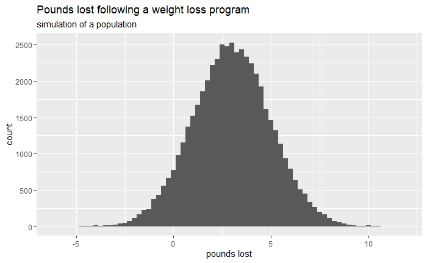

## Randomly select 3 samples of size 100 from the population

`r`r set.seed(19657) s1 <- sample_n(my_pop, 100, replace = TRUE) s2 <- sample_n(my_pop, 100, replace = TRUE) s3 <- sample_n(my_pop, 100, replace = TRUE)

## Calculate the mean for each random sample

`r`r mean(s1$p_lbslost)

```
[1] 2.9345
```

`r`r mean(s2$p_lbslost)

```
[1] 2.999346
```

`r`r mean(s3$p_lbslost)

```
[1] 3.07468
```

The means are all relatively similar to the population mean. The larger the sample sizes are the more likely they will approximate the mean.

# Inference for SLR

## Simulate a population based on SLR results

`r`r set.seed(83587) caldef <- rnorm (mean = 10.80, sd = 5.15, n = 100000) b0 <- -.12 b1 <- .29 sigma <- 2.1 e <- rnorm(mean = 0, sd = sigma, n = 100000) lbslost <- b0 + b1*caldef + e my_regpop <- data.frame(caldef, lbslost)

### Create scatterplot for population SLR

`r`r ggplot(my_regpop, aes(x = caldef, y = lbslost)) + geom_point() + geom_smooth(method = , se = FALSE) + labs(title = of Caloric Deficit and Pounds Lost, x = Deficit, y = Lost)

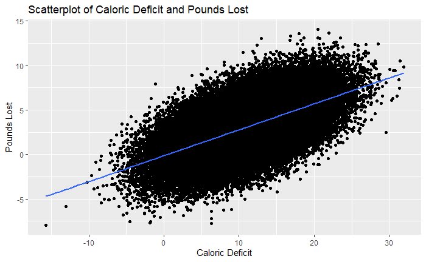

### Fit a Simple Linear regression (SLR) model of the population

`r`r popmod <- lm(lbslost ~ caldef, data = my_regpop) ols_regress(popmod)

```
                        Model Summary
--------------------------------------------------------------
R                       0.583       RMSE                2.094
R-Squared               0.339       Coef. Var          69.509
Adj. R-Squared          0.339       MSE                 4.386
Pred R-Squared          0.339       MAE                 1.671
--------------------------------------------------------------
 RMSE: Root Mean Square Error
 MSE: Mean Square Error
 MAE: Mean Absolute Error

                                   ANOVA
----------------------------------------------------------------------------
                  Sum of
                 Squares           DF    Mean Square        F          Sig.
----------------------------------------------------------------------------
Regression    225259.749            1     225259.749    51363.057    0.0000
Residual      438554.979        99998          4.386
Total         663814.728        99999
----------------------------------------------------------------------------

                                   Parameter Estimates
-----------------------------------------------------------------------------------------
      model      Beta    Std. Error    Std. Beta       t        Sig      lower     upper
-----------------------------------------------------------------------------------------
(Intercept)    -0.141         0.015                  -9.130    0.000    -0.171    -0.110
     caldef     0.292         0.001        0.583    226.634    0.000     0.289     0.294
-----------------------------------------------------------------------------------------
```

## Randomly select 3 samples of 100 from the population

`r`r s1 <- sample_n(my_regpop, 100, replace = TRUE) s2 <- sample_n(my_regpop, 100, replace = TRUE) s3 <- sample_n(my_regpop, 100, replace = TRUE)

## Fit an SLR to each random sample

`r`r ols_regress(lm(data = s1, lbslost ~ caldef))

```
                        Model Summary
--------------------------------------------------------------
R                       0.634       RMSE                2.042
R-Squared               0.401       Coef. Var          72.625
Adj. R-Squared          0.395       MSE                 4.169
Pred R-Squared          0.377       MAE                 1.518
--------------------------------------------------------------
 RMSE: Root Mean Square Error
 MSE: Mean Square Error
 MAE: Mean Absolute Error

                               ANOVA
-------------------------------------------------------------------
               Sum of
              Squares        DF    Mean Square      F         Sig.
-------------------------------------------------------------------
Regression    273.946         1        273.946    65.706    0.0000
Residual      408.589        98          4.169
Total         682.535        99
-------------------------------------------------------------------

                                  Parameter Estimates
---------------------------------------------------------------------------------------
      model      Beta    Std. Error    Std. Beta      t        Sig      lower    upper
---------------------------------------------------------------------------------------
(Intercept)    -0.618         0.470                 -1.316    0.191    -1.551    0.314
     caldef     0.329         0.041        0.634     8.106    0.000     0.248    0.410
---------------------------------------------------------------------------------------
```

`r`r ols_regress(lm(data = s2, lbslost ~ caldef))

```
                        Model Summary
--------------------------------------------------------------
R                       0.564       RMSE                2.183
R-Squared               0.318       Coef. Var          75.716
Adj. R-Squared          0.311       MSE                 4.767
Pred R-Squared          0.293       MAE                 1.679
--------------------------------------------------------------
 RMSE: Root Mean Square Error
 MSE: Mean Square Error
 MAE: Mean Absolute Error

                               ANOVA
-------------------------------------------------------------------
               Sum of
              Squares        DF    Mean Square      F         Sig.
-------------------------------------------------------------------
Regression    217.548         1        217.548    45.636    0.0000
Residual      467.171        98          4.767
Total         684.720        99
-------------------------------------------------------------------

                                  Parameter Estimates
---------------------------------------------------------------------------------------
      model      Beta    Std. Error    Std. Beta      t        Sig      lower    upper
---------------------------------------------------------------------------------------
(Intercept)    -0.451         0.540                 -0.836    0.405    -1.522    0.620
     caldef     0.296         0.044        0.564     6.755    0.000     0.209    0.383
---------------------------------------------------------------------------------------
```

`r`r ols_regress(lm(data = s3, lbslost ~ caldef))

```
                        Model Summary
--------------------------------------------------------------
R                       0.549       RMSE                2.058
R-Squared               0.302       Coef. Var          64.576
Adj. R-Squared          0.295       MSE                 4.236
Pred R-Squared          0.278       MAE                 1.674
--------------------------------------------------------------
 RMSE: Root Mean Square Error
 MSE: Mean Square Error
 MAE: Mean Absolute Error

                               ANOVA
-------------------------------------------------------------------
               Sum of
              Squares        DF    Mean Square      F         Sig.
-------------------------------------------------------------------
Regression    179.564         1        179.564    42.387    0.0000
Residual      415.159        98          4.236
Total         594.723        99
-------------------------------------------------------------------

                                 Parameter Estimates
-------------------------------------------------------------------------------------
      model     Beta    Std. Error    Std. Beta      t       Sig      lower    upper
-------------------------------------------------------------------------------------
(Intercept)    0.583         0.450                 1.297    0.198    -0.309    1.476
     caldef    0.247         0.038        0.549    6.511    0.000     0.172    0.322
-------------------------------------------------------------------------------------
```

Although each model varies slightly, it is seen that the sample intercepts and slopes are relatively similar to the population intercept and slope. Each intercept and slope confidence interval contains the true population value. If we run these tests 100 times, the true population value will likely be contain in the confidence intervals 95 times. We also see that the standard errors increased when we took the samples of 100.